# COVIDEDA (some W203 lab 2 data explorations)

### No perfect collinearity?

This assumption is satisfied if `lm()` did not drop coefficients:

```r
ourmodel$coefficients
```

```
##                  (Intercept)           percent_in_poverty
##                  588.7063038                    4.9861907
##                      pop_den             house_per_capita
##                    0.1402569                  370.2632551
## hs_or_higher_25_plus_percent              pct_age_85_plus
##                -1242.7708616                 4023.4040427
```

We can also check correlations between variables:

```r
cor(select(data_cleaned, percent_in_poverty, house_per_capita))
```

```
##                    percent_in_poverty house_per_capita
## percent_in_poverty          1.0000000        0.1556594
## house_per_capita            0.1556594        1.0000000
```

### Homoskedastic errors?

1. check if the Breusch-Pagan test already rejects the null hypothesis that we have homoskedasticity:

```r
bptest(ourmodel)
```

```
##
##  studentized Breusch-Pagan test
##
## data:  ourmodel
## BP = 5.7812, df = 5, p-value = 0.3281
```

```r
bptest(model1)
```

```
##
##  studentized Breusch-Pagan test
##
## data:  model1
## BP = 4.0398, df = 2, p-value = 0.1327
```

```r
bptest(model2)
```

```
##
##  studentized Breusch-Pagan test
##
## data:  model2
## BP = 4.7562, df = 3, p-value = 0.1905
```

```r
bptest(model3)
```

```
##
##  studentized Breusch-Pagan test
##
## data:  model3
## BP = 8.5541, df = 4, p-value = 0.07327
```

```r
bptest(model4)
```

```
##
##  studentized Breusch-Pagan test
##
## data:  model4
## BP = 5.7812, df = 5, p-value = 0.3281
```

```r
bptest(model5)
```

```
##
##  studentized Breusch-Pagan test
##
## data:  model5
## BP = 5.7596, df = 6, p-value = 0.4507
```

```r
bptest(model6)
```

```
##
##  studentized Breusch-Pagan test
##
## data:  model6
## BP = 5.7165, df = 7, p-value = 0.5732
```

```r
if (max_num_predictors >= 7) {
bptest(model7)
}
if (max_num_predictors >= 8) {
bptest(model8)
}
```

2. Again eyeball the first plot of residuals vs. predictions in the “Linear conditional expectation” section above, this time to check how much the height of the grey band varies

and/or

3. eyeball the scale-location plot, where the smoothed curve should look flat:

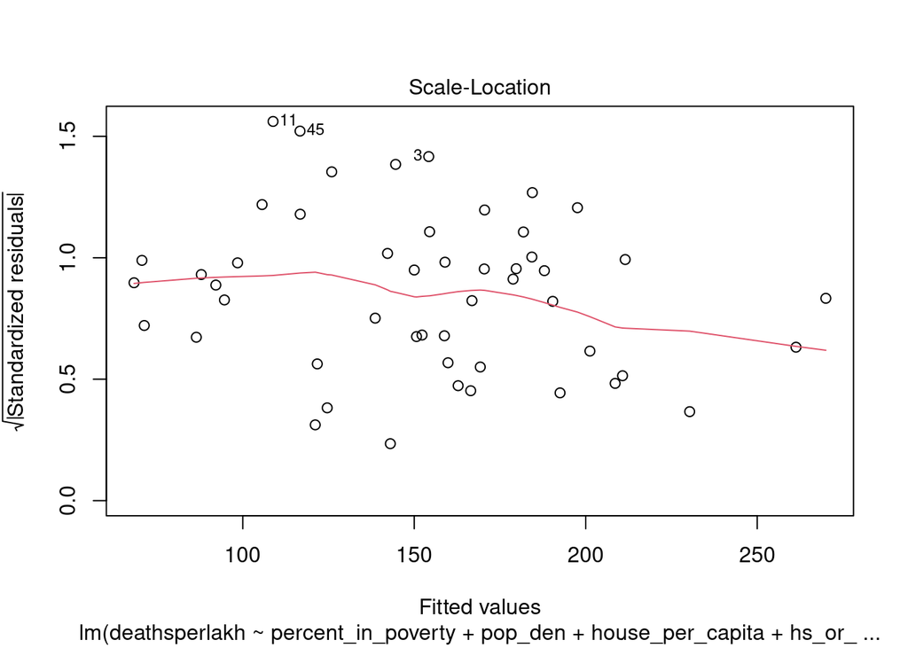

```r
plot(ourmodel, which = 3)
```

### Normally distributed errors?

1. check if the Shapiro-Wilk test already rejects the null hypothesis that the residuals are normally distributed:

```r
shapiro.test(resid(ourmodel))
```

```
##
##  Shapiro-Wilk normality test
##
## data:  resid(ourmodel)
## W = 0.98481, p-value = 0.7636
```

and/or

2. eyeball the QQ-plot:

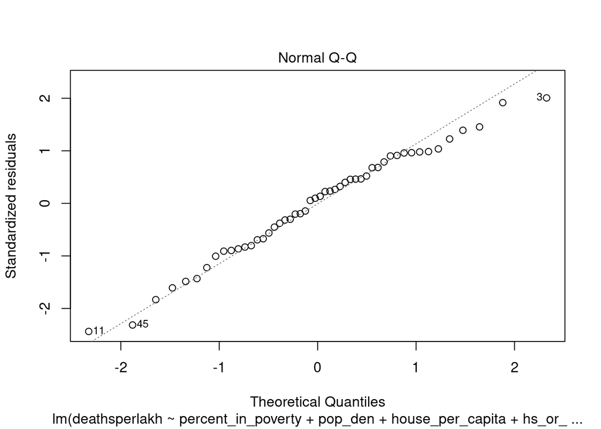

```r
plot(ourmodel, which=2)
```

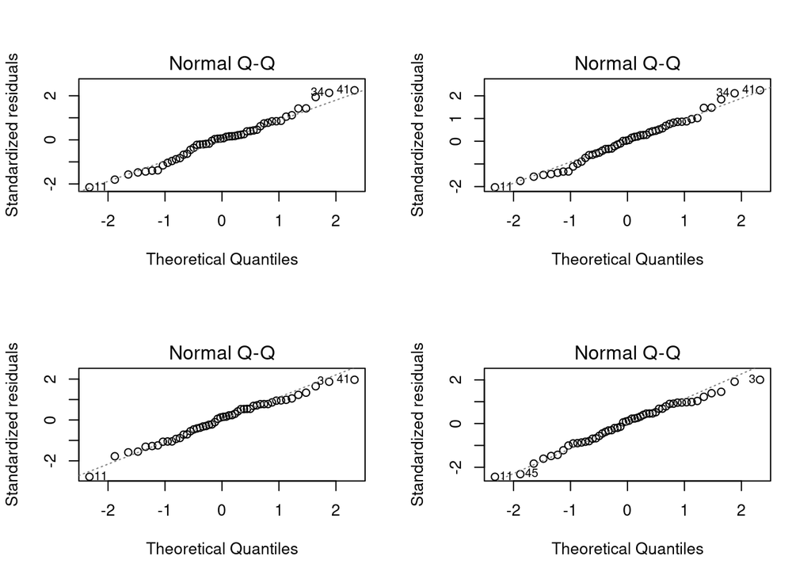

```r
par(mfrow = c(2, 2))

plot(model1, which=2)
plot(model2, which=2)
plot(model3, which=2)
plot(model4, which=2)
```

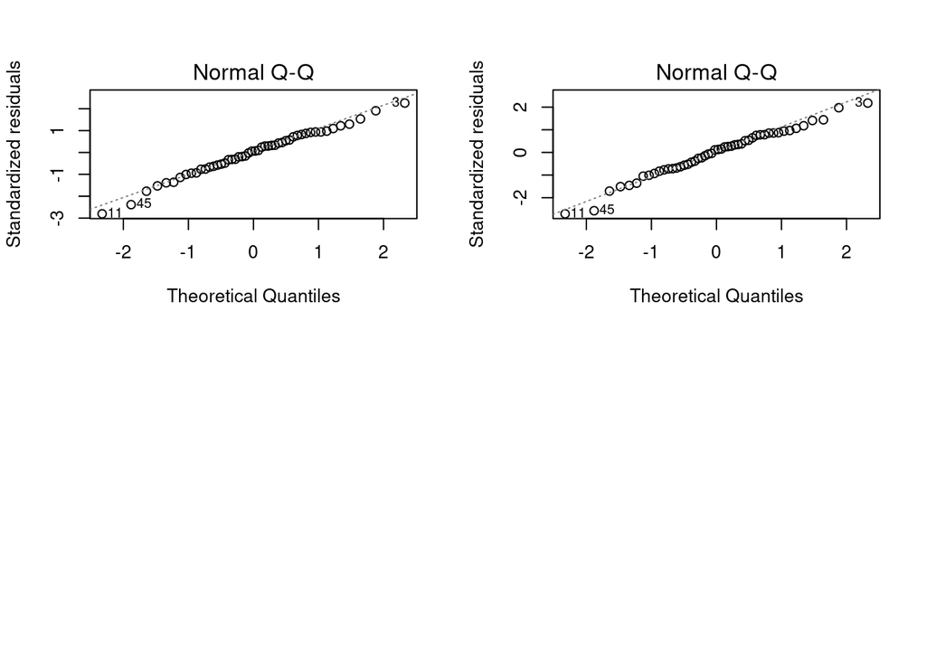

```r
plot(model5, which=2)
plot(model6, which=2)
if (max_num_predictors >= 7) {
plot(model7, which=2)
}
if (max_num_predictors >= 8) {
plot(model8, which=2)
}
```

# Other Graphs

[figure not shown]

## Calculate cases on a time interval (from Kevin)

(Kevin:)

```r
start.date <- as.Date("2021-01-01")
end.date <- as.Date("2021-02-28")
interval.cases <- NYT_Data[date == end.date, cases] - NYT_Data[date == start.date, cases]
```

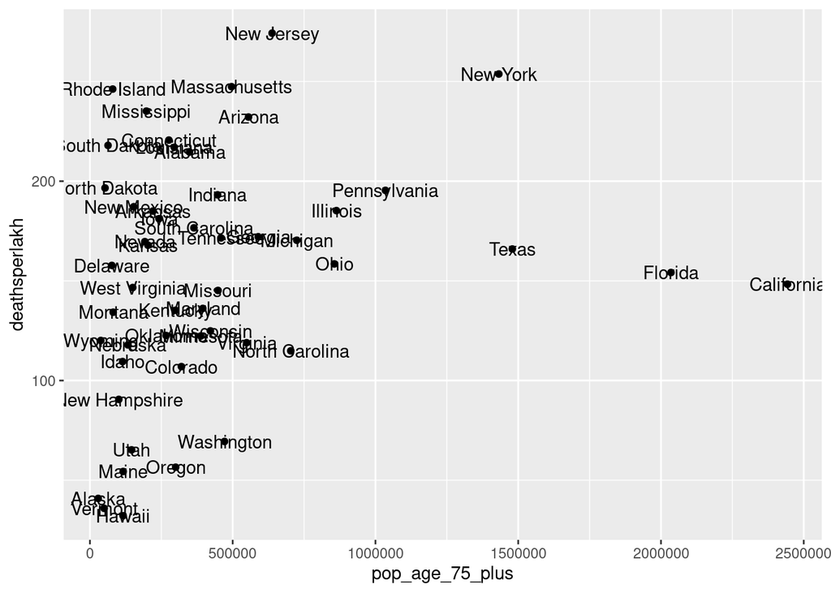

[figure not shown]

```r
ggplot(data_cleaned, aes(x=pop_age_75_plus, y=deathsperlakh)) +
  geom_point() +
  geom_text(aes(label = state))
```